# E-Commerce_EDA_Stats

```python
import pandas as pd ; import numpy as np
```

```python
import warnings
warnings.filterwarnings("ignore")
```

### Data importing:

```python
olist_cust = pd.read_csv('olist_customers_dataset.csv')
olist_geo = pd.read_csv('olist_geolocation_dataset.csv')
olist_ordi = pd.read_csv('olist_order_items_dataset.csv')
olist_ordp = pd.read_csv('olist_order_payments_dataset.csv')
olist_ordr = pd.read_csv('olist_order_reviews_dataset.csv')
olist_ordd = pd.read_csv('olist_orders_dataset.csv')
olist_prod = pd.read_csv('olist_products_dataset.csv')
olist_sel = pd.read_csv('olist_sellers_dataset.csv')
olist_pcat = pd.read_csv('product_category_name_translation.csv')
```

### Data Analysing:

```python
print('olist_customers_dataset',olist_cust.shape)
print('olist_geolocation_dataset',olist_geo.shape)
print('olist_order_items_dataset',olist_ordi.shape)
print('olist_order_payments_dataset',olist_ordp.shape)
print('olist_order_reviews_dataset',olist_ordr.shape)
print('olist_orders_dataset',olist_ordd.shape)
print('olist_products_dataset',olist_prod.shape)
print('olist_sellers_dataset',olist_sel.shape)
print('product_category_name_translation',olist_pcat.shape)
```

```
olist_customers_dataset (99441, 5)
olist_geolocation_dataset (1000163, 5)
olist_order_items_dataset (112650, 7)
olist_order_payments_dataset (103886, 5)
olist_order_reviews_dataset (100000, 7)
olist_orders_dataset (99441, 8)
olist_products_dataset (32951, 9)
olist_sellers_dataset (3095, 4)
product_category_name_translation (71, 2)
```

### Data Preparation:

```python
print(olist_cust.columns)
print()
print(olist_geo.columns)
print()
print(olist_ordi.columns)
print()
print(olist_ordp.columns)
print()
print(olist_ordr.columns)
print()
print(olist_ordd.columns)
print()
print(olist_prod.columns)
print()
print(olist_sel.columns)
print()
print(olist_pcat.columns)
```

```
Index(['customer_id', 'customer_unique_id', 'customer_zip_code_prefix',
       'customer_city', 'customer_state'],
      dtype='object')

Index(['geolocation_zip_code_prefix', 'geolocation_lat', 'geolocation_lng',
       'geolocation_city', 'geolocation_state'],
      dtype='object')

Index(['order_id', 'order_item_id', 'product_id', 'seller_id',
       'shipping_limit_date', 'price', 'freight_value'],
      dtype='object')

Index(['order_id', 'payment_sequential', 'payment_type',
       'payment_installments', 'payment_value'],
      dtype='object')

Index(['review_id', 'order_id', 'review_score', 'review_comment_title',
       'review_comment_message', 'review_creation_date',
       'review_answer_timestamp'],
      dtype='object')

Index(['order_id', 'customer_id', 'order_status', 'order_purchase_timestamp',
       'order_approved_at', 'order_delivered_carrier_date',
       'order_delivered_customer_date', 'order_estimated_delivery_date'],
      dtype='object')

Index(['product_id', 'product_category_name', 'product_name_lenght',
       'product_description_lenght', 'product_photos_qty', 'product_weight_g',
       'product_length_cm', 'product_height_cm', 'product_width_cm'],
      dtype='object')

Index(['seller_id', 'seller_zip_code_prefix', 'seller_city', 'seller_state'], dtype='object')

Index(['product_category_name', 'product_category_name_english'], dtype='object')
```

### Data Merging:

```python
df1 = pd.merge(olist_cust ,olist_ordd, on='customer_id', how='outer')

df2 = pd.merge(olist_ordi ,olist_ordp, on='order_id', how='outer')

df3 = pd.merge(df2, olist_ordr , on='order_id', how='outer' )

df4 = pd.merge(df3, olist_sel , on='seller_id', how='outer' )

df5 = pd.merge(df1,df4, on='order_id', how='outer' )

df6 = pd.merge(df5,olist_prod, on='product_id', how='outer' )

df7 = pd.merge(df6,olist_pcat, on='product_category_name', how='outer' )
```

### Null values and Engineering:

```python
print('Dimension of the data:',df7.shape)
print()
print('Total Null values:',df7.isna().sum().sum())
print()
print('Total Values in the data:',df7.values.size)
print()
print('The data has total',round((202203/4766040)*100,2),'% null values.')
```

```
Dimension of the data: (119151, 40)

Total Null values: 202203

Total Values in the data: 4766040

The data has total 4.24 % null values.
```

```python
df7.columns
```

```
Index(['customer_id', 'customer_unique_id', 'customer_zip_code_prefix',
       'customer_city', 'customer_state', 'order_id', 'order_status',
       'order_purchase_timestamp', 'order_approved_at',
       'order_delivered_carrier_date', 'order_delivered_customer_date',
       'order_estimated_delivery_date', 'order_item_id', 'product_id',
       'seller_id', 'shipping_limit_date', 'price', 'freight_value',
       'payment_sequential', 'payment_type', 'payment_installments',
       'payment_value', 'review_id', 'review_score', 'review_comment_title',
       'review_comment_message', 'review_creation_date',
       'review_answer_timestamp', 'seller_zip_code_prefix', 'seller_city',
       'seller_state', 'product_category_name', 'product_name_lenght',
       'product_description_lenght', 'product_photos_qty', 'product_weight_g',
       'product_length_cm', 'product_height_cm', 'product_width_cm',
       'product_category_name_english'],
      dtype='object')
```

```python
df7 = df7[~((df7['order_purchase_timestamp'].isna())|
     (df7['order_approved_at'].isna())|
     (df7['order_delivered_carrier_date'].isna())|
     (df7['order_delivered_customer_date'].isna())|
     (df7['order_estimated_delivery_date'].isna()))]
```

```python
df7.isna().sum()
```

```
customer_id                           0
customer_unique_id                    0
customer_zip_code_prefix              0
customer_city                         0
customer_state                        0
order_id                              0
order_status                          0
order_purchase_timestamp              0
order_approved_at                     0
order_delivered_carrier_date          0
order_delivered_customer_date         0
order_estimated_delivery_date         0
order_item_id                         0
product_id                            0
seller_id                             0
shipping_limit_date                   0
price                                 0
freight_value                         0
payment_sequential                    3
payment_type                          3
payment_installments                  3
payment_value                         3
review_id                             0
review_score                          0
review_comment_title             101967
review_comment_message            66756
review_creation_date                  0
review_answer_timestamp               0
seller_zip_code_prefix                0
seller_city                           0
seller_state                          0
product_category_name              1637
product_name_lenght                1637
product_description_lenght         1637
product_photos_qty                 1637
product_weight_g                     20
product_length_cm                    20
product_height_cm                    20
product_width_cm                     20
product_category_name_english      1660
dtype: int64
```

### Numerical and Categorical Datasets:

```python
print('Numerical features:',df7.select_dtypes(exclude = object).shape)
print()
print('Categorical features:',df7.select_dtypes(include = object).shape)
```

```
Numerical features: (115714, 16)

Categorical features: (115714, 24)
```

### Final Data Preparation:

```python
df7_cat = df7.select_dtypes(include = object)
df7_num = df7.select_dtypes(exclude = object)
```

```python
df7_cat.shape, df7_num.shape
```

```
((115714, 24), (115714, 16))
```

```python
print(df7_cat.columns)
print()
print(df7_num.columns)
```

```
Index(['customer_id', 'customer_unique_id', 'customer_city', 'customer_state',
       'order_id', 'order_status', 'order_purchase_timestamp',
       'order_approved_at', 'order_delivered_carrier_date',
       'order_delivered_customer_date', 'order_estimated_delivery_date',
       'product_id', 'seller_id', 'shipping_limit_date', 'payment_type',
       'review_id', 'review_comment_title', 'review_comment_message',
       'review_creation_date', 'review_answer_timestamp', 'seller_city',
       'seller_state', 'product_category_name',
       'product_category_name_english'],
      dtype='object')

Index(['customer_zip_code_prefix', 'order_item_id', 'price', 'freight_value',
       'payment_sequential', 'payment_installments', 'payment_value',
       'review_score', 'seller_zip_code_prefix', 'product_name_lenght',
       'product_description_lenght', 'product_photos_qty', 'product_weight_g',
       'product_length_cm', 'product_height_cm', 'product_width_cm'],
      dtype='object')
```

# Working on Numerical Data

```python
df7_num.head()
```

|  | customer_zip_code_prefix | order_item_id | price | freight_value | payment_sequential | payment_installments | payment_value | review_score | seller_zip_code_prefix | product_name_lenght | product_description_lenght | product_photos_qty | product_weight_g | product_length_cm | product_height_cm | product_width_cm |
| --- | --- | --- | --- | --- | --- | --- | --- | --- | --- | --- | --- | --- | --- | --- | --- | --- |
| 0 | 14409 | 1.0 | 124.99 | 21.88 | 1.0 | 2.0 | 146.87 | 4 | 8577.0 | 41.0 | 1141.0 | 1.0 | 8683.0 | 54.0 | 64.0 | 31.0 |
| 1 | 68030 | 1.0 | 112.99 | 24.90 | 1.0 | 1.0 | 275.79 | 1 | 8577.0 | 41.0 | 1141.0 | 1.0 | 8683.0 | 54.0 | 64.0 | 31.0 |
| 2 | 68030 | 2.0 | 112.99 | 24.90 | 1.0 | 1.0 | 275.79 | 1 | 8577.0 | 41.0 | 1141.0 | 1.0 | 8683.0 | 54.0 | 64.0 | 31.0 |
| 3 | 92480 | 1.0 | 124.99 | 15.62 | 1.0 | 7.0 | 140.61 | 3 | 8577.0 | 41.0 | 1141.0 | 1.0 | 8683.0 | 54.0 | 64.0 | 31.0 |
| 4 | 25931 | 1.0 | 106.99 | 30.59 | 1.0 | 10.0 | 137.58 | 4 | 8577.0 | 41.0 | 1141.0 | 1.0 | 8683.0 | 54.0 | 64.0 | 31.0 |

```python
df7_num.shape
```

```
(115714, 16)
```

```python
df7_num.isna().sum()/df7_num.shape[0]
```

```
customer_zip_code_prefix      0.000000
order_item_id                 0.000000
price                         0.000000
freight_value                 0.000000
payment_sequential            0.000026
payment_installments          0.000026
payment_value                 0.000026
review_score                  0.000000
seller_zip_code_prefix        0.000000
product_name_lenght           0.014147
product_description_lenght    0.014147
product_photos_qty            0.014147
product_weight_g              0.000173
product_length_cm             0.000173
product_height_cm             0.000173
product_width_cm              0.000173
dtype: float64
```

```python
print(np.unique(df7_num.payment_sequential))
print()
print(np.unique(df7_num.payment_installments))
print()
print(np.unique(df7_num.product_name_lenght))
```

```
[ 1.  2.  3.  4.  5.  6.  7.  8.  9. 10. 11. 12. 13. 14. 15. 16. 17. 18.
 19. 20. 21. 22. 23. 24. 25. 26. nan nan nan]

[ 0.  1.  2.  3.  4.  5.  6.  7.  8.  9. 10. 11. 12. 13. 14. 15. 16. 17.
 18. 20. 21. 22. 23. 24. nan nan nan]

[ 5.  6.  7. ... nan nan nan]
```

Since we have a little data missing, hence we are going to apply `KNN Imputer` for directly. It won't affect the data much. Since we are about to drop nan values for Data-Time feature.

```python
df7_num.isna().sum()
```

```
customer_zip_code_prefix         0
order_item_id                    0
price                            0
freight_value                    0
payment_sequential               3
payment_installments             3
payment_value                    3
review_score                     0
seller_zip_code_prefix           0
product_name_lenght           1637
product_description_lenght    1637
product_photos_qty            1637
product_weight_g                20
product_length_cm               20
product_height_cm               20
product_width_cm                20
dtype: int64
```

```python
df7_num['product_name_lenght']=df7_num['product_name_lenght'].fillna(df7_num.groupby('customer_zip_code_prefix')['product_name_lenght'].transform('mean'))
```

```python
df7_num['product_description_lenght']=df7_num['product_description_lenght'].fillna(df7_num.groupby('order_item_id')['product_description_lenght'].transform('mean'))
```

```python
df7_num['product_photos_qty']=df7_num['product_photos_qty'].fillna(df7_num.groupby('order_item_id')['product_photos_qty'].transform('mean'))
```

```python
df7_num['product_weight_g']=df7_num['product_weight_g'].fillna(df7_num.groupby('price')['product_weight_g'].transform('mean'))
```

```python
df7_num['product_length_cm']=df7_num['product_length_cm'].fillna(df7_num.groupby('price')['product_length_cm'].transform('mean'))
```

```python
df7_num['product_height_cm']=df7_num['product_height_cm'].fillna(df7_num.groupby('price')['product_height_cm'].transform('mean'))
```

```python
df7_num['product_width_cm']=df7_num['product_width_cm'].fillna(df7_num.groupby('price')['product_width_cm'].transform('mean'))
```

```python
df7_num.isna().sum()
```

```
customer_zip_code_prefix       0
order_item_id                  0
price                          0
freight_value                  0
payment_sequential             3
payment_installments           3
payment_value                  3
review_score                   0
seller_zip_code_prefix         0
product_name_lenght           62
product_description_lenght     0
product_photos_qty             0
product_weight_g               1
product_length_cm              1
product_height_cm              1
product_width_cm               1
dtype: int64
```

`Since data is quite longer, hence knn imputer did not work properly. We changed our plan of imputation.

```python
DATA = pd.concat((df7_num, df7_cat), axis = 1)
DATA.shape, df7.shape
```

```
((115714, 40), (115714, 40))
```

```python
DATA.isna().sum()
```

```
customer_zip_code_prefix              0
order_item_id                         0
price                                 0
freight_value                         0
payment_sequential                    3
payment_installments                  3
payment_value                         3
review_score                          0
seller_zip_code_prefix                0
product_name_lenght                  62
product_description_lenght            0
product_photos_qty                    0
product_weight_g                      1
product_length_cm                     1
product_height_cm                     1
product_width_cm                      1
customer_id                           0
customer_unique_id                    0
customer_city                         0
customer_state                        0
order_id                              0
order_status                          0
order_purchase_timestamp              0
order_approved_at                     0
order_delivered_carrier_date          0
order_delivered_customer_date         0
order_estimated_delivery_date         0
product_id                            0
seller_id                             0
shipping_limit_date                   0
payment_type                          3
review_id                             0
review_comment_title             101967
review_comment_message            66756
review_creation_date                  0
review_answer_timestamp               0
seller_city                           0
seller_state                          0
product_category_name              1637
product_category_name_english      1660
dtype: int64
```

```python
DATA = DATA.drop(['review_comment_message', 'review_comment_title'], axis = 1)
```

```python
#DATA['seller_city'] = DATA['seller_city'].fillna(DATA['seller_city'].mode().values[0])
#DATA['seller_state'] = DATA['seller_state'].fillna(DATA['seller_state'].mode().values[0])
DATA['payment_type'] = DATA['payment_type'].fillna(DATA.groupby(['order_item_id', 'customer_id'])['payment_type'].agg(pd.Series.mode).values[0])
#DATA['seller_id'] = DATA['seller_id'].fillna(DATA['seller_id'].mode().values[0])
#DATA['product_id'] = DATA['product_id'].fillna(DATA['product_id'].mode().values[0])
DATA['product_category_name_english'] = DATA['product_category_name_english'].fillna(DATA.groupby(['order_item_id', 'price'])['product_category_name_english'].agg(pd.Series.mode).values[0])
```

```python
DATA.isna().sum()
```

```
customer_zip_code_prefix            0
order_item_id                       0
price                               0
freight_value                       0
payment_sequential                  3
payment_installments                3
payment_value                       3
review_score                        0
seller_zip_code_prefix              0
product_name_lenght                62
product_description_lenght          0
product_photos_qty                  0
product_weight_g                    1
product_length_cm                   1
product_height_cm                   1
product_width_cm                    1
customer_id                         0
customer_unique_id                  0
customer_city                       0
customer_state                      0
order_id                            0
order_status                        0
order_purchase_timestamp            0
order_approved_at                   0
order_delivered_carrier_date        0
order_delivered_customer_date       0
order_estimated_delivery_date       0
product_id                          0
seller_id                           0
shipping_limit_date                 0
payment_type                        0
review_id                           0
review_creation_date                0
review_answer_timestamp             0
seller_city                         0
seller_state                        0
product_category_name            1637
product_category_name_english       0
dtype: int64
```

```python
data = DATA.drop('product_category_name', axis = 1)
```

```python
data = DATA.dropna(axis = 0)
```

```python
data.shape, df7.shape
```

```
((114073, 38), (115714, 40))
```

```python
data.isna().sum()
```

```
customer_zip_code_prefix         0
order_item_id                    0
price                            0
freight_value                    0
payment_sequential               0
payment_installments             0
payment_value                    0
review_score                     0
seller_zip_code_prefix           0
product_name_lenght              0
product_description_lenght       0
product_photos_qty               0
product_weight_g                 0
product_length_cm                0
product_height_cm                0
product_width_cm                 0
customer_id                      0
customer_unique_id               0
customer_city                    0
customer_state                   0
order_id                         0
order_status                     0
order_purchase_timestamp         0
order_approved_at                0
order_delivered_carrier_date     0
order_delivered_customer_date    0
order_estimated_delivery_date    0
product_id                       0
seller_id                        0
shipping_limit_date              0
payment_type                     0
review_id                        0
review_creation_date             0
review_answer_timestamp          0
seller_city                      0
seller_state                     0
product_category_name            0
product_category_name_english    0
dtype: int64
```

We dropped 2 unnecessery attributes.

# Working on Categorical Data:

```python
df7_cat = data.select_dtypes(include = object)
df7_num = data.select_dtypes(exclude = object)
```

```python
df7_cat.dtypes
```

```
customer_id                      object
customer_unique_id               object
customer_city                    object
customer_state                   object
order_id                         object
order_status                     object
order_purchase_timestamp         object
order_approved_at                object
order_delivered_carrier_date     object
order_delivered_customer_date    object
order_estimated_delivery_date    object
product_id                       object
seller_id                        object
shipping_limit_date              object
payment_type                     object
review_id                        object
review_creation_date             object
review_answer_timestamp          object
seller_city                      object
seller_state                     object
product_category_name            object
product_category_name_english    object
dtype: object
```

```python
df7_cat.isna().sum()/df7_cat.shape[0]
```

```
customer_id                      0.0
customer_unique_id               0.0
customer_city                    0.0
customer_state                   0.0
order_id                         0.0
order_status                     0.0
order_purchase_timestamp         0.0
order_approved_at                0.0
order_delivered_carrier_date     0.0
order_delivered_customer_date    0.0
order_estimated_delivery_date    0.0
product_id                       0.0
seller_id                        0.0
shipping_limit_date              0.0
payment_type                     0.0
review_id                        0.0
review_creation_date             0.0
review_answer_timestamp          0.0
seller_city                      0.0
seller_state                     0.0
product_category_name            0.0
product_category_name_english    0.0
dtype: float64
```

We drop `review_comment_message` from the data, since it has a lot of null values.

```python
df7_cat['order_purchase_timestamp'] = pd.to_datetime(df7_cat['order_purchase_timestamp'])
df7_cat['order_approved_at'] = pd.to_datetime(df7_cat['order_approved_at'])
df7_cat['order_delivered_carrier_date'] = pd.to_datetime(df7_cat['order_delivered_carrier_date'])
df7_cat['order_estimated_delivery_date'] = pd.to_datetime(df7_cat['order_estimated_delivery_date'])
df7_cat['shipping_limit_date'] = pd.to_datetime(df7_cat['shipping_limit_date'])
df7_cat['review_creation_date'] = pd.to_datetime(df7_cat['review_creation_date'])
df7_cat['review_answer_timestamp'] = pd.to_datetime(df7_cat['review_answer_timestamp'])
df7_cat['order_delivered_customer_date'] = pd.to_datetime(df7_cat['order_delivered_customer_date'])
```

```python
df7_cat.dtypes
```

```
customer_id                              object
customer_unique_id                       object
customer_city                            object
customer_state                           object
order_id                                 object
order_status                             object
order_purchase_timestamp         datetime64[ns]
order_approved_at                datetime64[ns]
order_delivered_carrier_date     datetime64[ns]
order_delivered_customer_date    datetime64[ns]
order_estimated_delivery_date    datetime64[ns]
product_id                               object
seller_id                                object
shipping_limit_date              datetime64[ns]
payment_type                             object
review_id                                object
review_creation_date             datetime64[ns]
review_answer_timestamp          datetime64[ns]
seller_city                              object
seller_state                             object
product_category_name                    object
product_category_name_english            object
dtype: object
```

```python
print(df7_cat['product_category_name_english'].value_counts())
print('*'*100)
print(df7_cat['product_category_name'].value_counts())
```

```
bed_bath_table               11815
health_beauty                 9816
sports_leisure                8790
furniture_decor               8640
computers_accessories         7963
                             ...
arts_and_craftmanship           24
la_cuisine                      16
cds_dvds_musicals               14
fashion_childrens_clothes        7
security_and_services            2
Name: product_category_name_english, Length: 71, dtype: int64
cama_mesa_banho                                  11815
beleza_saude                                      9816
esporte_lazer                                     8790
moveis_decoracao                                  8640
informatica_acessorios                            7963
                                                 ...
portateis_cozinha_e_preparadores_de_alimentos       14
cds_dvds_musicais                                   14
pc_gamer                                             9
fashion_roupa_infanto_juvenil                        7
seguros_e_servicos                                   2
Name: product_category_name, Length: 73, dtype: int64
```

```python
name_eng = df7_cat['product_category_name_english'].value_counts().index
name_braz = df7_cat['product_category_name'].value_counts().index
```

```python
from deep_translator import GoogleTranslator
to_translate = 'cama_mesa_banho'
translated = GoogleTranslator(source='portuguese', target='english').translate(to_translate)
translated
```

```
'bed table bath'
```

Let us apply on data the `Translation` function.

```python
from deep_translator import GoogleTranslator

name_braz_to_eng = []

for i in name_braz:
    to_translate = i
    translated = GoogleTranslator(source='portuguese', target='english').translate(to_translate)
    name_braz_to_eng.append(translated)
```

```python
print(name_braz_to_eng)
print()
print(name_eng)
```

[output not shown]

```python
furniture = ['bed_bath_table', 'furniture_decor', 'furniture_living_room', 'kitchen_dining_laundry_garden_furniture',
            'furniture_bedroom', 'furniture_mattress_and_upholstery']
sports_fashion = ['sports_leisure', 'consoles_games', 'fashion_shoes','art', 'fashion_underwear_beach', 'fashion_male_clothing',
         'fashio_female_clothing', 'party_supplies', 'music', 'fashion_sport', 'arts_and_craftmanship', 'cds_dvds_musicals',
                 'fashion_childrens_clothes']
households = ['telephony', 'watches_gifts' , 'home_appliances_2','housewares', 'market_place', 'drinks',
              'food_drink', 'home_confort', 'audio', 'food','electronics', 'garden_tools', 'auto', 'toys',
              'cool_stuff', 'perfumery', 'home_appliances', 'small_appliances_home_oven_and_coffee', 'flowers',
             'home_comfort_2', 'la_cuisine']
computer_office = ['computers_accessories', 'stationery', 'office_furniture', 'books_general_interest',
                   'air_conditioning', 'books_technical', 'industry_commerce_and_business', 'fixed_telephony','computers',
                  'cine_photo', 'dvds_blu_ray', 'books_imported']
health_medicinies = ['health_beauty', 'baby', 'pet_shop', 'agro_industry_and_commerce', 'tablets_printing_image',
                    'diapers_and_hygiene']
Electronics = ['Electronics','signaling_and_security', 'christmas_supplies', 'security_and_services']
cosmetics_accessories =  ['fashion_bags_accessories', 'luggage_accessories']
Construction = ['construction_tools_construction', 'home_construction', 'construction_tools_lights',
                'costruction_tools_garden', 'construction_tools_safety', 'costruction_tools_tools']
```

`portuguese` and `English` columns are both same with a litle count change. Hence we are removing a columns from the data again.

```python
df7_cat = df7_cat.drop('product_category_name', axis = 1)
```

```python
prod = []
for i in df7_cat.product_category_name_english:
    if i in furniture:
        prod.append('Furniture')
    elif i in sports_fashion:
        prod.append('Sports_Fashion')
    elif i in households:
        prod.append('Households')
    elif i in computer_office:
        prod.append('Computer_Office')
    elif i in health_medicinies:
        prod.append('Health_Medicinies')
    elif i in Electronics:
        prod.append('Electronics')
    elif i in cosmetics_accessories:
        prod.append('Cosmetics_accessories')
    else:
        prod.append('Construction')
```

```python
df7_cat.isna().sum()
```

```
customer_id                      0
customer_unique_id               0
customer_city                    0
customer_state                   0
order_id                         0
order_status                     0
order_purchase_timestamp         0
order_approved_at                0
order_delivered_carrier_date     0
order_delivered_customer_date    0
order_estimated_delivery_date    0
product_id                       0
seller_id                        0
shipping_limit_date              0
payment_type                     0
review_id                        0
review_creation_date             0
review_answer_timestamp          0
seller_city                      0
seller_state                     0
product_category_name_english    0
dtype: int64
```

```python
df7_cat.dtypes
```

```
customer_id                              object
customer_unique_id                       object
customer_city                            object
customer_state                           object
order_id                                 object
order_status                             object
order_purchase_timestamp         datetime64[ns]
order_approved_at                datetime64[ns]
order_delivered_carrier_date     datetime64[ns]
order_delivered_customer_date    datetime64[ns]
order_estimated_delivery_date    datetime64[ns]
product_id                               object
seller_id                                object
shipping_limit_date              datetime64[ns]
payment_type                             object
review_id                                object
review_creation_date             datetime64[ns]
review_answer_timestamp          datetime64[ns]
seller_city                              object
seller_state                             object
product_category_name_english            object
dtype: object
```

```python
df7_cat.head()
```

|  | customer_id | customer_unique_id | customer_city | customer_state | order_id | order_status | order_purchase_timestamp | order_approved_at | order_delivered_carrier_date | order_delivered_customer_date | ... | product_id | seller_id | shipping_limit_date | payment_type | review_id | review_creation_date | review_answer_timestamp | seller_city | seller_state | product_category_name_english |
| --- | --- | --- | --- | --- | --- | --- | --- | --- | --- | --- | --- | --- | --- | --- | --- | --- | --- | --- | --- | --- | --- |
| 0 | 06b8999e2fba1a1fbc88172c00ba8bc7 | 861eff4711a542e4b93843c6dd7febb0 | franca | SP | 00e7ee1b050b8499577073aeb2a297a1 | delivered | 2017-05-16 15:05:35 | 2017-05-16 15:22:12 | 2017-05-23 10:47:57 | 2017-05-25 10:35:35 | ... | a9516a079e37a9c9c36b9b78b10169e8 | 7c67e1448b00f6e969d365cea6b010ab | 2017-05-22 15:22:12 | credit_card | 88b8b52d46df026a9d1ad2136a59b30b | 2017-05-26 | 2017-05-30 22:34:40 | itaquaquecetuba | SP | office_furniture |
| 1 | 8912fc0c3bbf1e2fbf35819e21706718 | 9eae34bbd3a474ec5d07949ca7de67c0 | santarem | PA | c1d2b34febe9cd269e378117d6681172 | delivered | 2017-11-09 00:50:13 | 2017-11-10 00:47:48 | 2017-11-22 01:43:37 | 2017-11-28 00:09:50 | ... | a9516a079e37a9c9c36b9b78b10169e8 | 7c67e1448b00f6e969d365cea6b010ab | 2017-11-23 00:47:18 | credit_card | 7fc63200f12eebb5f387856afdd63db8 | 2017-11-29 | 2017-12-01 19:41:59 | itaquaquecetuba | SP | office_furniture |
| 2 | 8912fc0c3bbf1e2fbf35819e21706718 | 9eae34bbd3a474ec5d07949ca7de67c0 | santarem | PA | c1d2b34febe9cd269e378117d6681172 | delivered | 2017-11-09 00:50:13 | 2017-11-10 00:47:48 | 2017-11-22 01:43:37 | 2017-11-28 00:09:50 | ... | a9516a079e37a9c9c36b9b78b10169e8 | 7c67e1448b00f6e969d365cea6b010ab | 2017-11-23 00:47:18 | credit_card | 7fc63200f12eebb5f387856afdd63db8 | 2017-11-29 | 2017-12-01 19:41:59 | itaquaquecetuba | SP | office_furniture |
| 3 | f0ac8e5a239118859b1734e1087cbb1f | 3c799d181c34d51f6d44bbbc563024db | nova santa rita | RS | b1a5d5365d330d10485e0203d54ab9e8 | delivered | 2017-05-07 20:11:26 | 2017-05-08 22:22:56 | 2017-05-19 20:16:31 | 2017-05-26 09:54:04 | ... | a9516a079e37a9c9c36b9b78b10169e8 | 7c67e1448b00f6e969d365cea6b010ab | 2017-05-22 22:22:56 | credit_card | 251191809e37c1cffc16865947c18a4d | 2017-05-27 | 2017-05-28 02:43:16 | itaquaquecetuba | SP | office_furniture |
| 4 | 6bc8d08963a135220ed6c6d098831f84 | 23397e992b09769faf5e66f9e171a241 | mage | RJ | 2e604b3614664aa66867856dba7e61b7 | delivered | 2018-02-03 19:45:40 | 2018-02-04 22:29:19 | 2018-02-19 18:21:47 | 2018-02-28 21:09:00 | ... | a9516a079e37a9c9c36b9b78b10169e8 | 7c67e1448b00f6e969d365cea6b010ab | 2018-02-18 21:29:19 | credit_card | f7123bac5b91a0e2e38d8b41fd1206f4 | 2018-03-01 | 2018-03-02 11:11:24 | itaquaquecetuba | SP | office_furniture |

5 rows × 21 columns

```python
df7_cat['product_category_name_english'] = prod
```

```python
df7_cat = df7_cat.rename(columns = {'product_category_name_english' : 'product'})
```

```python
df7_cat.to_csv('categorical_data.csv')
```

```python
df7_cat = pd.get_dummies(df7_cat, columns=['product'])
```

```python
X = df7_cat.copy()
```

```python
X1 = X.iloc[:,:11]
X1.head(3)
```

|  | customer_id | customer_unique_id | customer_city | customer_state | order_id | order_status | order_purchase_timestamp | order_approved_at | order_delivered_carrier_date | order_delivered_customer_date | order_estimated_delivery_date |
| --- | --- | --- | --- | --- | --- | --- | --- | --- | --- | --- | --- |
| 0 | 06b8999e2fba1a1fbc88172c00ba8bc7 | 861eff4711a542e4b93843c6dd7febb0 | franca | SP | 00e7ee1b050b8499577073aeb2a297a1 | delivered | 2017-05-16 15:05:35 | 2017-05-16 15:22:12 | 2017-05-23 10:47:57 | 2017-05-25 10:35:35 | 2017-06-05 |
| 1 | 8912fc0c3bbf1e2fbf35819e21706718 | 9eae34bbd3a474ec5d07949ca7de67c0 | santarem | PA | c1d2b34febe9cd269e378117d6681172 | delivered | 2017-11-09 00:50:13 | 2017-11-10 00:47:48 | 2017-11-22 01:43:37 | 2017-11-28 00:09:50 | 2017-12-19 |
| 2 | 8912fc0c3bbf1e2fbf35819e21706718 | 9eae34bbd3a474ec5d07949ca7de67c0 | santarem | PA | c1d2b34febe9cd269e378117d6681172 | delivered | 2017-11-09 00:50:13 | 2017-11-10 00:47:48 | 2017-11-22 01:43:37 | 2017-11-28 00:09:50 | 2017-12-19 |

```python
print(X1.order_status.unique())
```

```
['delivered' 'canceled']
```

```python
X1 = X1.replace(to_replace = ['delivered', 'canceled'], value = [1,0])
```

```python
X1.head(3)
```

|  | customer_id | customer_unique_id | customer_city | customer_state | order_id | order_status | order_purchase_timestamp | order_approved_at | order_delivered_carrier_date | order_delivered_customer_date | order_estimated_delivery_date |
| --- | --- | --- | --- | --- | --- | --- | --- | --- | --- | --- | --- |
| 0 | 06b8999e2fba1a1fbc88172c00ba8bc7 | 861eff4711a542e4b93843c6dd7febb0 | franca | SP | 00e7ee1b050b8499577073aeb2a297a1 | 1 | 2017-05-16 15:05:35 | 2017-05-16 15:22:12 | 2017-05-23 10:47:57 | 2017-05-25 10:35:35 | 2017-06-05 |
| 1 | 8912fc0c3bbf1e2fbf35819e21706718 | 9eae34bbd3a474ec5d07949ca7de67c0 | santarem | PA | c1d2b34febe9cd269e378117d6681172 | 1 | 2017-11-09 00:50:13 | 2017-11-10 00:47:48 | 2017-11-22 01:43:37 | 2017-11-28 00:09:50 | 2017-12-19 |
| 2 | 8912fc0c3bbf1e2fbf35819e21706718 | 9eae34bbd3a474ec5d07949ca7de67c0 | santarem | PA | c1d2b34febe9cd269e378117d6681172 | 1 | 2017-11-09 00:50:13 | 2017-11-10 00:47:48 | 2017-11-22 01:43:37 | 2017-11-28 00:09:50 | 2017-12-19 |

Let us make some more features corresponding to the existing features.

```python
X1['order_approved_at'] = pd.to_datetime(X1.order_approved_at.dt.date)
X1['order_delivered_customer_date'] = pd.to_datetime(X1.order_delivered_customer_date.dt.date)
X1['order_purchase_timestamp'] = pd.to_datetime(X1.order_purchase_timestamp.dt.date)
X1['order_delivered_carrier_date'] = pd.to_datetime(X1.order_delivered_carrier_date.dt.date)
X1['order_estimated_delivery_date'] = pd.to_datetime(X1.order_estimated_delivery_date.dt.date)
```

```python
X1.head()
```

|  | customer_id | customer_unique_id | customer_city | customer_state | order_id | order_status | order_purchase_timestamp | order_approved_at | order_delivered_carrier_date | order_delivered_customer_date | order_estimated_delivery_date |
| --- | --- | --- | --- | --- | --- | --- | --- | --- | --- | --- | --- |
| 0 | 06b8999e2fba1a1fbc88172c00ba8bc7 | 861eff4711a542e4b93843c6dd7febb0 | franca | SP | 00e7ee1b050b8499577073aeb2a297a1 | 1 | 2017-05-16 | 2017-05-16 | 2017-05-23 | 2017-05-25 | 2017-06-05 |
| 1 | 8912fc0c3bbf1e2fbf35819e21706718 | 9eae34bbd3a474ec5d07949ca7de67c0 | santarem | PA | c1d2b34febe9cd269e378117d6681172 | 1 | 2017-11-09 | 2017-11-10 | 2017-11-22 | 2017-11-28 | 2017-12-19 |
| 2 | 8912fc0c3bbf1e2fbf35819e21706718 | 9eae34bbd3a474ec5d07949ca7de67c0 | santarem | PA | c1d2b34febe9cd269e378117d6681172 | 1 | 2017-11-09 | 2017-11-10 | 2017-11-22 | 2017-11-28 | 2017-12-19 |
| 3 | f0ac8e5a239118859b1734e1087cbb1f | 3c799d181c34d51f6d44bbbc563024db | nova santa rita | RS | b1a5d5365d330d10485e0203d54ab9e8 | 1 | 2017-05-07 | 2017-05-08 | 2017-05-19 | 2017-05-26 | 2017-06-12 |
| 4 | 6bc8d08963a135220ed6c6d098831f84 | 23397e992b09769faf5e66f9e171a241 | mage | RJ | 2e604b3614664aa66867856dba7e61b7 | 1 | 2018-02-03 | 2018-02-04 | 2018-02-19 | 2018-02-28 | 2018-03-22 |

```python
f1 = X1.order_delivered_customer_date - X1.order_approved_at

c = pd.DataFrame()
c['order_delivered_customer_date'] = X1.order_delivered_customer_date
c['order_approved_at'] = X1.order_approved_at
c['b'] = f1
c['b'] = (c['b'].values/86400000000000).astype(int)
c['b'] = np.where((c.b < 0),c['b'].mean(),c.b)
```

```python
c.head()
```

|  | order_delivered_customer_date | order_approved_at | b |
| --- | --- | --- | --- |
| 0 | 2017-05-25 | 2017-05-16 | 9.0 |
| 1 | 2017-11-28 | 2017-11-10 | 18.0 |
| 2 | 2017-11-28 | 2017-11-10 | 18.0 |
| 3 | 2017-05-26 | 2017-05-08 | 18.0 |
| 4 | 2018-02-28 | 2018-02-04 | 24.0 |

```python
c.isna().sum()
```

```
order_delivered_customer_date    0
order_approved_at                0
b                                0
dtype: int64
```

Since the `df.values` coming in the form of nano-seconds, we were unable to deal with proper date difference. We approached above scenario.

```python
X1['Delivered_item_in_days'] = c['b'].values
```

```python
X1.head()
```

|  | customer_id | customer_unique_id | customer_city | customer_state | order_id | order_status | order_purchase_timestamp | order_approved_at | order_delivered_carrier_date | order_delivered_customer_date | order_estimated_delivery_date | Delivered_item_in_days |
| --- | --- | --- | --- | --- | --- | --- | --- | --- | --- | --- | --- | --- |
| 0 | 06b8999e2fba1a1fbc88172c00ba8bc7 | 861eff4711a542e4b93843c6dd7febb0 | franca | SP | 00e7ee1b050b8499577073aeb2a297a1 | 1 | 2017-05-16 | 2017-05-16 | 2017-05-23 | 2017-05-25 | 2017-06-05 | 9.0 |
| 1 | 8912fc0c3bbf1e2fbf35819e21706718 | 9eae34bbd3a474ec5d07949ca7de67c0 | santarem | PA | c1d2b34febe9cd269e378117d6681172 | 1 | 2017-11-09 | 2017-11-10 | 2017-11-22 | 2017-11-28 | 2017-12-19 | 18.0 |
| 2 | 8912fc0c3bbf1e2fbf35819e21706718 | 9eae34bbd3a474ec5d07949ca7de67c0 | santarem | PA | c1d2b34febe9cd269e378117d6681172 | 1 | 2017-11-09 | 2017-11-10 | 2017-11-22 | 2017-11-28 | 2017-12-19 | 18.0 |
| 3 | f0ac8e5a239118859b1734e1087cbb1f | 3c799d181c34d51f6d44bbbc563024db | nova santa rita | RS | b1a5d5365d330d10485e0203d54ab9e8 | 1 | 2017-05-07 | 2017-05-08 | 2017-05-19 | 2017-05-26 | 2017-06-12 | 18.0 |
| 4 | 6bc8d08963a135220ed6c6d098831f84 | 23397e992b09769faf5e66f9e171a241 | mage | RJ | 2e604b3614664aa66867856dba7e61b7 | 1 | 2018-02-03 | 2018-02-04 | 2018-02-19 | 2018-02-28 | 2018-03-22 | 24.0 |

```python
f2 = X1.order_estimated_delivery_date - X1.order_delivered_customer_date

c1 = pd.DataFrame()
c1['order_estimated_delivery_date'] = X1.order_estimated_delivery_date
c1['order_approved_at'] = X1.order_delivered_customer_date
c1['b'] = f2
c1['b'] = (c1['b'].values/86400000000000).astype(int)
c1['b'] = np.where((c1.b < 0),c1['b'].mean(),c1.b)
```

```python
c1.head()
```

|  | order_estimated_delivery_date | order_approved_at | b |
| --- | --- | --- | --- |
| 0 | 2017-06-05 | 2017-05-25 | 11.0 |
| 1 | 2017-12-19 | 2017-11-28 | 21.0 |
| 2 | 2017-12-19 | 2017-11-28 | 21.0 |
| 3 | 2017-06-12 | 2017-05-26 | 17.0 |
| 4 | 2018-03-22 | 2018-02-28 | 22.0 |

```python
c1.isna().sum()
```

```
order_estimated_delivery_date    0
order_approved_at                0
b                                0
dtype: int64
```

```python
X1['Quickness_in_deliveries_days'] = c1['b'].values
```

```python
X1.head()
```

|  | customer_id | customer_unique_id | customer_city | customer_state | order_id | order_status | order_purchase_timestamp | order_approved_at | order_delivered_carrier_date | order_delivered_customer_date | order_estimated_delivery_date | Delivered_item_in_days | Quickness_in_deliveries_days |
| --- | --- | --- | --- | --- | --- | --- | --- | --- | --- | --- | --- | --- | --- |
| 0 | 06b8999e2fba1a1fbc88172c00ba8bc7 | 861eff4711a542e4b93843c6dd7febb0 | franca | SP | 00e7ee1b050b8499577073aeb2a297a1 | 1 | 2017-05-16 | 2017-05-16 | 2017-05-23 | 2017-05-25 | 2017-06-05 | 9.0 | 11.0 |
| 1 | 8912fc0c3bbf1e2fbf35819e21706718 | 9eae34bbd3a474ec5d07949ca7de67c0 | santarem | PA | c1d2b34febe9cd269e378117d6681172 | 1 | 2017-11-09 | 2017-11-10 | 2017-11-22 | 2017-11-28 | 2017-12-19 | 18.0 | 21.0 |
| 2 | 8912fc0c3bbf1e2fbf35819e21706718 | 9eae34bbd3a474ec5d07949ca7de67c0 | santarem | PA | c1d2b34febe9cd269e378117d6681172 | 1 | 2017-11-09 | 2017-11-10 | 2017-11-22 | 2017-11-28 | 2017-12-19 | 18.0 | 21.0 |
| 3 | f0ac8e5a239118859b1734e1087cbb1f | 3c799d181c34d51f6d44bbbc563024db | nova santa rita | RS | b1a5d5365d330d10485e0203d54ab9e8 | 1 | 2017-05-07 | 2017-05-08 | 2017-05-19 | 2017-05-26 | 2017-06-12 | 18.0 | 17.0 |
| 4 | 6bc8d08963a135220ed6c6d098831f84 | 23397e992b09769faf5e66f9e171a241 | mage | RJ | 2e604b3614664aa66867856dba7e61b7 | 1 | 2018-02-03 | 2018-02-04 | 2018-02-19 | 2018-02-28 | 2018-03-22 | 24.0 | 22.0 |

This `Quickness_in_deliveries_days` feature shows that, delivery was expected at a time, but got *earlier* by these days.

```python
f3 = X1.order_approved_at - X1.order_purchase_timestamp

c2 = pd.DataFrame()
c2['order_approved_at'] = X1.order_approved_at
c2['order_purchase_timestamp'] = X1.order_purchase_timestamp
c2['b'] = f3
c2['b'] = (c2['b'].values/86400000000000).astype(int)
c2['b'] = np.where((c2.b < 0),c2['b'].mean(),c2.b)
```

```python
c2.head()
```

|  | order_approved_at | order_purchase_timestamp | b |
| --- | --- | --- | --- |
| 0 | 2017-05-16 | 2017-05-16 | 0.0 |
| 1 | 2017-11-10 | 2017-11-09 | 1.0 |
| 2 | 2017-11-10 | 2017-11-09 | 1.0 |
| 3 | 2017-05-08 | 2017-05-07 | 1.0 |
| 4 | 2018-02-04 | 2018-02-03 | 1.0 |

```python
c2.isna().sum()
```

```
order_approved_at           0
order_purchase_timestamp    0
b                           0
dtype: int64
```

```python
X1['Quickness_in_approval_in_days'] = c2['b'].values
```

```python
X1.head()
```

|  | customer_id | customer_unique_id | customer_city | customer_state | order_id | order_status | order_purchase_timestamp | order_approved_at | order_delivered_carrier_date | order_delivered_customer_date | order_estimated_delivery_date | Delivered_item_in_days | Quickness_in_deliveries_days | Quickness_in_approval_in_days |
| --- | --- | --- | --- | --- | --- | --- | --- | --- | --- | --- | --- | --- | --- | --- |
| 0 | 06b8999e2fba1a1fbc88172c00ba8bc7 | 861eff4711a542e4b93843c6dd7febb0 | franca | SP | 00e7ee1b050b8499577073aeb2a297a1 | 1 | 2017-05-16 | 2017-05-16 | 2017-05-23 | 2017-05-25 | 2017-06-05 | 9.0 | 11.0 | 0.0 |
| 1 | 8912fc0c3bbf1e2fbf35819e21706718 | 9eae34bbd3a474ec5d07949ca7de67c0 | santarem | PA | c1d2b34febe9cd269e378117d6681172 | 1 | 2017-11-09 | 2017-11-10 | 2017-11-22 | 2017-11-28 | 2017-12-19 | 18.0 | 21.0 | 1.0 |
| 2 | 8912fc0c3bbf1e2fbf35819e21706718 | 9eae34bbd3a474ec5d07949ca7de67c0 | santarem | PA | c1d2b34febe9cd269e378117d6681172 | 1 | 2017-11-09 | 2017-11-10 | 2017-11-22 | 2017-11-28 | 2017-12-19 | 18.0 | 21.0 | 1.0 |
| 3 | f0ac8e5a239118859b1734e1087cbb1f | 3c799d181c34d51f6d44bbbc563024db | nova santa rita | RS | b1a5d5365d330d10485e0203d54ab9e8 | 1 | 2017-05-07 | 2017-05-08 | 2017-05-19 | 2017-05-26 | 2017-06-12 | 18.0 | 17.0 | 1.0 |
| 4 | 6bc8d08963a135220ed6c6d098831f84 | 23397e992b09769faf5e66f9e171a241 | mage | RJ | 2e604b3614664aa66867856dba7e61b7 | 1 | 2018-02-03 | 2018-02-04 | 2018-02-19 | 2018-02-28 | 2018-03-22 | 24.0 | 22.0 | 1.0 |

This feature `Quickness_in_approval_days`shows after how many days the order got accepted. This can show the service of the product.

```python
f4 = X1.order_delivered_carrier_date - X1.order_approved_at

c3 = pd.DataFrame()
c3['order_delivered_carrier_date'] = X1.order_delivered_carrier_date
c3['order_approved_at'] = X1.order_approved_at
c3['b'] = f4
c3['b'] = (c3['b'].values/86400000000000).astype(int)
c3['b'] = np.where((c3.b < 0),c3['b'].mean(),c3.b)
```

```python
c3.head()
```

|  | order_delivered_carrier_date | order_approved_at | b |
| --- | --- | --- | --- |
| 0 | 2017-05-23 | 2017-05-16 | 7.0 |
| 1 | 2017-11-22 | 2017-11-10 | 12.0 |
| 2 | 2017-11-22 | 2017-11-10 | 12.0 |
| 3 | 2017-05-19 | 2017-05-08 | 11.0 |
| 4 | 2018-02-19 | 2018-02-04 | 15.0 |

```python
c3.isna().sum()
```

```
order_delivered_carrier_date    0
order_approved_at               0
b                               0
dtype: int64
```

```python
X1['Quickness_in_loading_in_days'] = c3['b'].values
```

```python
X1.head()
```

|  | customer_id | customer_unique_id | customer_city | customer_state | order_id | order_status | order_purchase_timestamp | order_approved_at | order_delivered_carrier_date | order_delivered_customer_date | order_estimated_delivery_date | Delivered_item_in_days | Quickness_in_deliveries_days | Quickness_in_approval_in_days | Quickness_in_loading_in_days |
| --- | --- | --- | --- | --- | --- | --- | --- | --- | --- | --- | --- | --- | --- | --- | --- |
| 0 | 06b8999e2fba1a1fbc88172c00ba8bc7 | 861eff4711a542e4b93843c6dd7febb0 | franca | SP | 00e7ee1b050b8499577073aeb2a297a1 | 1 | 2017-05-16 | 2017-05-16 | 2017-05-23 | 2017-05-25 | 2017-06-05 | 9.0 | 11.0 | 0.0 | 7.0 |
| 1 | 8912fc0c3bbf1e2fbf35819e21706718 | 9eae34bbd3a474ec5d07949ca7de67c0 | santarem | PA | c1d2b34febe9cd269e378117d6681172 | 1 | 2017-11-09 | 2017-11-10 | 2017-11-22 | 2017-11-28 | 2017-12-19 | 18.0 | 21.0 | 1.0 | 12.0 |
| 2 | 8912fc0c3bbf1e2fbf35819e21706718 | 9eae34bbd3a474ec5d07949ca7de67c0 | santarem | PA | c1d2b34febe9cd269e378117d6681172 | 1 | 2017-11-09 | 2017-11-10 | 2017-11-22 | 2017-11-28 | 2017-12-19 | 18.0 | 21.0 | 1.0 | 12.0 |
| 3 | f0ac8e5a239118859b1734e1087cbb1f | 3c799d181c34d51f6d44bbbc563024db | nova santa rita | RS | b1a5d5365d330d10485e0203d54ab9e8 | 1 | 2017-05-07 | 2017-05-08 | 2017-05-19 | 2017-05-26 | 2017-06-12 | 18.0 | 17.0 | 1.0 | 11.0 |
| 4 | 6bc8d08963a135220ed6c6d098831f84 | 23397e992b09769faf5e66f9e171a241 | mage | RJ | 2e604b3614664aa66867856dba7e61b7 | 1 | 2018-02-03 | 2018-02-04 | 2018-02-19 | 2018-02-28 | 2018-03-22 | 24.0 | 22.0 | 1.0 | 15.0 |

This `Quickness_in_loading_in_days` feature shows, after how many days the product got loaded after booking. This also shows the service quality of the company or buisness.

```python
from collections import Counter
counter = Counter(X1['customer_city'])
counter1 = Counter(X1['customer_state'])
```

```python
X1['customer_city'] = X1['customer_city'].replace(counter)
X1['customer_state'] = X1['customer_state'].replace(counter1)
```

```python
X1.head()
```

|  | customer_id | customer_unique_id | customer_city | customer_state | order_id | order_status | order_purchase_timestamp | order_approved_at | order_delivered_carrier_date | order_delivered_customer_date | order_estimated_delivery_date | Delivered_item_in_days | Quickness_in_deliveries_days | Quickness_in_approval_in_days | Quickness_in_loading_in_days |
| --- | --- | --- | --- | --- | --- | --- | --- | --- | --- | --- | --- | --- | --- | --- | --- |
| 0 | 06b8999e2fba1a1fbc88172c00ba8bc7 | 861eff4711a542e4b93843c6dd7febb0 | 220 | 48121 | 00e7ee1b050b8499577073aeb2a297a1 | 1 | 2017-05-16 | 2017-05-16 | 2017-05-23 | 2017-05-25 | 2017-06-05 | 9.0 | 11.0 | 0.0 | 7.0 |
| 1 | 8912fc0c3bbf1e2fbf35819e21706718 | 9eae34bbd3a474ec5d07949ca7de67c0 | 47 | 1079 | c1d2b34febe9cd269e378117d6681172 | 1 | 2017-11-09 | 2017-11-10 | 2017-11-22 | 2017-11-28 | 2017-12-19 | 18.0 | 21.0 | 1.0 | 12.0 |
| 2 | 8912fc0c3bbf1e2fbf35819e21706718 | 9eae34bbd3a474ec5d07949ca7de67c0 | 47 | 1079 | c1d2b34febe9cd269e378117d6681172 | 1 | 2017-11-09 | 2017-11-10 | 2017-11-22 | 2017-11-28 | 2017-12-19 | 18.0 | 21.0 | 1.0 | 12.0 |
| 3 | f0ac8e5a239118859b1734e1087cbb1f | 3c799d181c34d51f6d44bbbc563024db | 7 | 6332 | b1a5d5365d330d10485e0203d54ab9e8 | 1 | 2017-05-07 | 2017-05-08 | 2017-05-19 | 2017-05-26 | 2017-06-12 | 18.0 | 17.0 | 1.0 | 11.0 |
| 4 | 6bc8d08963a135220ed6c6d098831f84 | 23397e992b09769faf5e66f9e171a241 | 138 | 14739 | 2e604b3614664aa66867856dba7e61b7 | 1 | 2018-02-03 | 2018-02-04 | 2018-02-19 | 2018-02-28 | 2018-03-22 | 24.0 | 22.0 | 1.0 | 15.0 |

```python
X2 = X.iloc[:,11:]
X2.head(3)
```

|  | product_id | seller_id | shipping_limit_date | payment_type | review_id | review_creation_date | review_answer_timestamp | seller_city | seller_state | product_Computer_Office | product_Construction | product_Cosmetics_accessories | product_Electronics | product_Furniture | product_Health_Medicinies | product_Households | product_Sports_Fashion |
| --- | --- | --- | --- | --- | --- | --- | --- | --- | --- | --- | --- | --- | --- | --- | --- | --- | --- |
| 0 | a9516a079e37a9c9c36b9b78b10169e8 | 7c67e1448b00f6e969d365cea6b010ab | 2017-05-22 15:22:12 | credit_card | 88b8b52d46df026a9d1ad2136a59b30b | 2017-05-26 | 2017-05-30 22:34:40 | itaquaquecetuba | SP | 1 | 0 | 0 | 0 | 0 | 0 | 0 | 0 |
| 1 | a9516a079e37a9c9c36b9b78b10169e8 | 7c67e1448b00f6e969d365cea6b010ab | 2017-11-23 00:47:18 | credit_card | 7fc63200f12eebb5f387856afdd63db8 | 2017-11-29 | 2017-12-01 19:41:59 | itaquaquecetuba | SP | 1 | 0 | 0 | 0 | 0 | 0 | 0 | 0 |
| 2 | a9516a079e37a9c9c36b9b78b10169e8 | 7c67e1448b00f6e969d365cea6b010ab | 2017-11-23 00:47:18 | credit_card | 7fc63200f12eebb5f387856afdd63db8 | 2017-11-29 | 2017-12-01 19:41:59 | itaquaquecetuba | SP | 1 | 0 | 0 | 0 | 0 | 0 | 0 | 0 |

```python
X2['review_creation_date'] = pd.to_datetime(X2.review_creation_date.dt.date)
X2['review_answer_timestamp'] = pd.to_datetime(X2.review_answer_timestamp.dt.date)
X2['shipping_limit_date'] = pd.to_datetime(X2.shipping_limit_date.dt.date)
```

```python
f5 = X2.review_answer_timestamp - X2.review_creation_date

c4 = pd.DataFrame()
c4['review_answer_timestamp'] = X2.review_answer_timestamp
c4['review_creation_date'] = X2.review_creation_date
c4['b'] = f5
c4['b'] = (c4['b'].values/86400000000000).astype(int)
c4['b'] = np.where((c4.b < 0),c4['b'].mean(),c4.b)
```

```python
c4.head()
```

|  | review_answer_timestamp | review_creation_date | b |
| --- | --- | --- | --- |
| 0 | 2017-05-30 | 2017-05-26 | 4.0 |
| 1 | 2017-12-01 | 2017-11-29 | 2.0 |
| 2 | 2017-12-01 | 2017-11-29 | 2.0 |
| 3 | 2017-05-28 | 2017-05-27 | 1.0 |
| 4 | 2018-03-02 | 2018-03-01 | 1.0 |

```python
X2['Review_Answer_within_days'] = c4['b']
```

```python
X2.head()
```

|  | product_id | seller_id | shipping_limit_date | payment_type | review_id | review_creation_date | review_answer_timestamp | seller_city | seller_state | product_Computer_Office | product_Construction | product_Cosmetics_accessories | product_Electronics | product_Furniture | product_Health_Medicinies | product_Households | product_Sports_Fashion | Review_Answer_within_days |
| --- | --- | --- | --- | --- | --- | --- | --- | --- | --- | --- | --- | --- | --- | --- | --- | --- | --- | --- |
| 0 | a9516a079e37a9c9c36b9b78b10169e8 | 7c67e1448b00f6e969d365cea6b010ab | 2017-05-22 | credit_card | 88b8b52d46df026a9d1ad2136a59b30b | 2017-05-26 | 2017-05-30 | itaquaquecetuba | SP | 1 | 0 | 0 | 0 | 0 | 0 | 0 | 0 | 4.0 |
| 1 | a9516a079e37a9c9c36b9b78b10169e8 | 7c67e1448b00f6e969d365cea6b010ab | 2017-11-23 | credit_card | 7fc63200f12eebb5f387856afdd63db8 | 2017-11-29 | 2017-12-01 | itaquaquecetuba | SP | 1 | 0 | 0 | 0 | 0 | 0 | 0 | 0 | 2.0 |
| 2 | a9516a079e37a9c9c36b9b78b10169e8 | 7c67e1448b00f6e969d365cea6b010ab | 2017-11-23 | credit_card | 7fc63200f12eebb5f387856afdd63db8 | 2017-11-29 | 2017-12-01 | itaquaquecetuba | SP | 1 | 0 | 0 | 0 | 0 | 0 | 0 | 0 | 2.0 |
| 3 | a9516a079e37a9c9c36b9b78b10169e8 | 7c67e1448b00f6e969d365cea6b010ab | 2017-05-22 | credit_card | 251191809e37c1cffc16865947c18a4d | 2017-05-27 | 2017-05-28 | itaquaquecetuba | SP | 1 | 0 | 0 | 0 | 0 | 0 | 0 | 0 | 1.0 |
| 4 | a9516a079e37a9c9c36b9b78b10169e8 | 7c67e1448b00f6e969d365cea6b010ab | 2018-02-18 | credit_card | f7123bac5b91a0e2e38d8b41fd1206f4 | 2018-03-01 | 2018-03-02 | itaquaquecetuba | SP | 1 | 0 | 0 | 0 | 0 | 0 | 0 | 0 | 1.0 |

```python
from sklearn.preprocessing import LabelEncoder
le = LabelEncoder()
X2['payment_type'] = le.fit_transform(X2['payment_type'])
```

```python
X2.head()
```

|  | product_id | seller_id | shipping_limit_date | payment_type | review_id | review_creation_date | review_answer_timestamp | seller_city | seller_state | product_Computer_Office | product_Construction | product_Cosmetics_accessories | product_Electronics | product_Furniture | product_Health_Medicinies | product_Households | product_Sports_Fashion | Review_Answer_within_days |
| --- | --- | --- | --- | --- | --- | --- | --- | --- | --- | --- | --- | --- | --- | --- | --- | --- | --- | --- |
| 0 | a9516a079e37a9c9c36b9b78b10169e8 | 7c67e1448b00f6e969d365cea6b010ab | 2017-05-22 | 1 | 88b8b52d46df026a9d1ad2136a59b30b | 2017-05-26 | 2017-05-30 | itaquaquecetuba | SP | 1 | 0 | 0 | 0 | 0 | 0 | 0 | 0 | 4.0 |
| 1 | a9516a079e37a9c9c36b9b78b10169e8 | 7c67e1448b00f6e969d365cea6b010ab | 2017-11-23 | 1 | 7fc63200f12eebb5f387856afdd63db8 | 2017-11-29 | 2017-12-01 | itaquaquecetuba | SP | 1 | 0 | 0 | 0 | 0 | 0 | 0 | 0 | 2.0 |
| 2 | a9516a079e37a9c9c36b9b78b10169e8 | 7c67e1448b00f6e969d365cea6b010ab | 2017-11-23 | 1 | 7fc63200f12eebb5f387856afdd63db8 | 2017-11-29 | 2017-12-01 | itaquaquecetuba | SP | 1 | 0 | 0 | 0 | 0 | 0 | 0 | 0 | 2.0 |
| 3 | a9516a079e37a9c9c36b9b78b10169e8 | 7c67e1448b00f6e969d365cea6b010ab | 2017-05-22 | 1 | 251191809e37c1cffc16865947c18a4d | 2017-05-27 | 2017-05-28 | itaquaquecetuba | SP | 1 | 0 | 0 | 0 | 0 | 0 | 0 | 0 | 1.0 |
| 4 | a9516a079e37a9c9c36b9b78b10169e8 | 7c67e1448b00f6e969d365cea6b010ab | 2018-02-18 | 1 | f7123bac5b91a0e2e38d8b41fd1206f4 | 2018-03-01 | 2018-03-02 | itaquaquecetuba | SP | 1 | 0 | 0 | 0 | 0 | 0 | 0 | 0 | 1.0 |

```python
from collections import Counter
counter2 = Counter(X2['seller_city'])
counter3 = Counter(X2['seller_state'])

X2['seller_city'] = X2['seller_city'].replace(counter2)
X2['seller_state'] = X2['seller_state'].replace(counter3)
```

```python
X2.columns
```

```
Index(['product_id', 'seller_id', 'shipping_limit_date', 'payment_type',
       'review_id', 'review_creation_date', 'review_answer_timestamp',
       'seller_city', 'seller_state', 'product_Computer_Office',
       'product_Construction', 'product_Cosmetics_accessories',
       'product_Electronics', 'product_Furniture', 'product_Health_Medicinies',
       'product_Households', 'product_Sports_Fashion',
       'Review_Answer_within_days'],
      dtype='object')
```

```python
X3 = X2.copy()
```

```python
X3.head()
```

|  | product_id | seller_id | shipping_limit_date | payment_type | review_id | review_creation_date | review_answer_timestamp | seller_city | seller_state | product_Computer_Office | product_Construction | product_Cosmetics_accessories | product_Electronics | product_Furniture | product_Health_Medicinies | product_Households | product_Sports_Fashion | Review_Answer_within_days |
| --- | --- | --- | --- | --- | --- | --- | --- | --- | --- | --- | --- | --- | --- | --- | --- | --- | --- | --- |
| 0 | a9516a079e37a9c9c36b9b78b10169e8 | 7c67e1448b00f6e969d365cea6b010ab | 2017-05-22 | 1 | 88b8b52d46df026a9d1ad2136a59b30b | 2017-05-26 | 2017-05-30 | 1747 | 81373 | 1 | 0 | 0 | 0 | 0 | 0 | 0 | 0 | 4.0 |
| 1 | a9516a079e37a9c9c36b9b78b10169e8 | 7c67e1448b00f6e969d365cea6b010ab | 2017-11-23 | 1 | 7fc63200f12eebb5f387856afdd63db8 | 2017-11-29 | 2017-12-01 | 1747 | 81373 | 1 | 0 | 0 | 0 | 0 | 0 | 0 | 0 | 2.0 |
| 2 | a9516a079e37a9c9c36b9b78b10169e8 | 7c67e1448b00f6e969d365cea6b010ab | 2017-11-23 | 1 | 7fc63200f12eebb5f387856afdd63db8 | 2017-11-29 | 2017-12-01 | 1747 | 81373 | 1 | 0 | 0 | 0 | 0 | 0 | 0 | 0 | 2.0 |
| 3 | a9516a079e37a9c9c36b9b78b10169e8 | 7c67e1448b00f6e969d365cea6b010ab | 2017-05-22 | 1 | 251191809e37c1cffc16865947c18a4d | 2017-05-27 | 2017-05-28 | 1747 | 81373 | 1 | 0 | 0 | 0 | 0 | 0 | 0 | 0 | 1.0 |
| 4 | a9516a079e37a9c9c36b9b78b10169e8 | 7c67e1448b00f6e969d365cea6b010ab | 2018-02-18 | 1 | f7123bac5b91a0e2e38d8b41fd1206f4 | 2018-03-01 | 2018-03-02 | 1747 | 81373 | 1 | 0 | 0 | 0 | 0 | 0 | 0 | 0 | 1.0 |

X1 and X3 are ready for further processing.

```python
X4 = pd.concat((X1, X3), axis = 1)
X4.shape, X3.shape
```

```
((114073, 33), (114073, 18))
```

```python
X4.head()
```

|  | customer_id | customer_unique_id | customer_city | customer_state | order_id | order_status | order_purchase_timestamp | order_approved_at | order_delivered_carrier_date | order_delivered_customer_date | ... | seller_state | product_Computer_Office | product_Construction | product_Cosmetics_accessories | product_Electronics | product_Furniture | product_Health_Medicinies | product_Households | product_Sports_Fashion | Review_Answer_within_days |
| --- | --- | --- | --- | --- | --- | --- | --- | --- | --- | --- | --- | --- | --- | --- | --- | --- | --- | --- | --- | --- | --- |
| 0 | 06b8999e2fba1a1fbc88172c00ba8bc7 | 861eff4711a542e4b93843c6dd7febb0 | 220 | 48121 | 00e7ee1b050b8499577073aeb2a297a1 | 1 | 2017-05-16 | 2017-05-16 | 2017-05-23 | 2017-05-25 | ... | 81373 | 1 | 0 | 0 | 0 | 0 | 0 | 0 | 0 | 4.0 |
| 1 | 8912fc0c3bbf1e2fbf35819e21706718 | 9eae34bbd3a474ec5d07949ca7de67c0 | 47 | 1079 | c1d2b34febe9cd269e378117d6681172 | 1 | 2017-11-09 | 2017-11-10 | 2017-11-22 | 2017-11-28 | ... | 81373 | 1 | 0 | 0 | 0 | 0 | 0 | 0 | 0 | 2.0 |
| 2 | 8912fc0c3bbf1e2fbf35819e21706718 | 9eae34bbd3a474ec5d07949ca7de67c0 | 47 | 1079 | c1d2b34febe9cd269e378117d6681172 | 1 | 2017-11-09 | 2017-11-10 | 2017-11-22 | 2017-11-28 | ... | 81373 | 1 | 0 | 0 | 0 | 0 | 0 | 0 | 0 | 2.0 |
| 3 | f0ac8e5a239118859b1734e1087cbb1f | 3c799d181c34d51f6d44bbbc563024db | 7 | 6332 | b1a5d5365d330d10485e0203d54ab9e8 | 1 | 2017-05-07 | 2017-05-08 | 2017-05-19 | 2017-05-26 | ... | 81373 | 1 | 0 | 0 | 0 | 0 | 0 | 0 | 0 | 1.0 |
| 4 | 6bc8d08963a135220ed6c6d098831f84 | 23397e992b09769faf5e66f9e171a241 | 138 | 14739 | 2e604b3614664aa66867856dba7e61b7 | 1 | 2018-02-03 | 2018-02-04 | 2018-02-19 | 2018-02-28 | ... | 81373 | 1 | 0 | 0 | 0 | 0 | 0 | 0 | 0 | 1.0 |

5 rows × 33 columns

```python
X4.columns
```

```
Index(['customer_id', 'customer_unique_id', 'customer_city', 'customer_state',
       'order_id', 'order_status', 'order_purchase_timestamp',
       'order_approved_at', 'order_delivered_carrier_date',
       'order_delivered_customer_date', 'order_estimated_delivery_date',
       'Delivered_item_in_days', 'Quickness_in_deliveries_days',
       'Quickness_in_approval_in_days', 'Quickness_in_loading_in_days',
       'product_id', 'seller_id', 'shipping_limit_date', 'payment_type',
       'review_id', 'review_creation_date', 'review_answer_timestamp',
       'seller_city', 'seller_state', 'product_Computer_Office',
       'product_Construction', 'product_Cosmetics_accessories',
       'product_Electronics', 'product_Furniture', 'product_Health_Medicinies',
       'product_Households', 'product_Sports_Fashion',
       'Review_Answer_within_days'],
      dtype='object')
```

```python
X5 = X4.copy()
```

```python
X5.head()
```

|  | customer_id | customer_unique_id | customer_city | customer_state | order_id | order_status | order_purchase_timestamp | order_approved_at | order_delivered_carrier_date | order_delivered_customer_date | ... | seller_state | product_Computer_Office | product_Construction | product_Cosmetics_accessories | product_Electronics | product_Furniture | product_Health_Medicinies | product_Households | product_Sports_Fashion | Review_Answer_within_days |
| --- | --- | --- | --- | --- | --- | --- | --- | --- | --- | --- | --- | --- | --- | --- | --- | --- | --- | --- | --- | --- | --- |
| 0 | 06b8999e2fba1a1fbc88172c00ba8bc7 | 861eff4711a542e4b93843c6dd7febb0 | 220 | 48121 | 00e7ee1b050b8499577073aeb2a297a1 | 1 | 2017-05-16 | 2017-05-16 | 2017-05-23 | 2017-05-25 | ... | 81373 | 1 | 0 | 0 | 0 | 0 | 0 | 0 | 0 | 4.0 |
| 1 | 8912fc0c3bbf1e2fbf35819e21706718 | 9eae34bbd3a474ec5d07949ca7de67c0 | 47 | 1079 | c1d2b34febe9cd269e378117d6681172 | 1 | 2017-11-09 | 2017-11-10 | 2017-11-22 | 2017-11-28 | ... | 81373 | 1 | 0 | 0 | 0 | 0 | 0 | 0 | 0 | 2.0 |
| 2 | 8912fc0c3bbf1e2fbf35819e21706718 | 9eae34bbd3a474ec5d07949ca7de67c0 | 47 | 1079 | c1d2b34febe9cd269e378117d6681172 | 1 | 2017-11-09 | 2017-11-10 | 2017-11-22 | 2017-11-28 | ... | 81373 | 1 | 0 | 0 | 0 | 0 | 0 | 0 | 0 | 2.0 |
| 3 | f0ac8e5a239118859b1734e1087cbb1f | 3c799d181c34d51f6d44bbbc563024db | 7 | 6332 | b1a5d5365d330d10485e0203d54ab9e8 | 1 | 2017-05-07 | 2017-05-08 | 2017-05-19 | 2017-05-26 | ... | 81373 | 1 | 0 | 0 | 0 | 0 | 0 | 0 | 0 | 1.0 |
| 4 | 6bc8d08963a135220ed6c6d098831f84 | 23397e992b09769faf5e66f9e171a241 | 138 | 14739 | 2e604b3614664aa66867856dba7e61b7 | 1 | 2018-02-03 | 2018-02-04 | 2018-02-19 | 2018-02-28 | ... | 81373 | 1 | 0 | 0 | 0 | 0 | 0 | 0 | 0 | 1.0 |

5 rows × 33 columns

```python
f6 = X5.order_delivered_customer_date - X5.shipping_limit_date

c5 = pd.DataFrame()
c5['order_delivered_customer_date'] = X5.order_delivered_customer_date
c5['shipping_limit_date'] = X5.shipping_limit_date
c5['b'] = f6
c5['b'] = (c5['b'].values/86400000000000).astype(float)
```

```python
c5.head()
```

|  | order_delivered_customer_date | shipping_limit_date | b |
| --- | --- | --- | --- |
| 0 | 2017-05-25 | 2017-05-22 | 3.0 |
| 1 | 2017-11-28 | 2017-11-23 | 5.0 |
| 2 | 2017-11-28 | 2017-11-23 | 5.0 |
| 3 | 2017-05-26 | 2017-05-22 | 4.0 |
| 4 | 2018-02-28 | 2018-02-18 | 10.0 |

```python
X5['Delivery_befor_time'] = c5['b']
```

```python
X5.head()
```

|  | customer_id | customer_unique_id | customer_city | customer_state | order_id | order_status | order_purchase_timestamp | order_approved_at | order_delivered_carrier_date | order_delivered_customer_date | ... | product_Computer_Office | product_Construction | product_Cosmetics_accessories | product_Electronics | product_Furniture | product_Health_Medicinies | product_Households | product_Sports_Fashion | Review_Answer_within_days | Delivery_befor_time |
| --- | --- | --- | --- | --- | --- | --- | --- | --- | --- | --- | --- | --- | --- | --- | --- | --- | --- | --- | --- | --- | --- |
| 0 | 06b8999e2fba1a1fbc88172c00ba8bc7 | 861eff4711a542e4b93843c6dd7febb0 | 220 | 48121 | 00e7ee1b050b8499577073aeb2a297a1 | 1 | 2017-05-16 | 2017-05-16 | 2017-05-23 | 2017-05-25 | ... | 1 | 0 | 0 | 0 | 0 | 0 | 0 | 0 | 4.0 | 3.0 |
| 1 | 8912fc0c3bbf1e2fbf35819e21706718 | 9eae34bbd3a474ec5d07949ca7de67c0 | 47 | 1079 | c1d2b34febe9cd269e378117d6681172 | 1 | 2017-11-09 | 2017-11-10 | 2017-11-22 | 2017-11-28 | ... | 1 | 0 | 0 | 0 | 0 | 0 | 0 | 0 | 2.0 | 5.0 |
| 2 | 8912fc0c3bbf1e2fbf35819e21706718 | 9eae34bbd3a474ec5d07949ca7de67c0 | 47 | 1079 | c1d2b34febe9cd269e378117d6681172 | 1 | 2017-11-09 | 2017-11-10 | 2017-11-22 | 2017-11-28 | ... | 1 | 0 | 0 | 0 | 0 | 0 | 0 | 0 | 2.0 | 5.0 |
| 3 | f0ac8e5a239118859b1734e1087cbb1f | 3c799d181c34d51f6d44bbbc563024db | 7 | 6332 | b1a5d5365d330d10485e0203d54ab9e8 | 1 | 2017-05-07 | 2017-05-08 | 2017-05-19 | 2017-05-26 | ... | 1 | 0 | 0 | 0 | 0 | 0 | 0 | 0 | 1.0 | 4.0 |
| 4 | 6bc8d08963a135220ed6c6d098831f84 | 23397e992b09769faf5e66f9e171a241 | 138 | 14739 | 2e604b3614664aa66867856dba7e61b7 | 1 | 2018-02-03 | 2018-02-04 | 2018-02-19 | 2018-02-28 | ... | 1 | 0 | 0 | 0 | 0 | 0 | 0 | 0 | 1.0 | 10.0 |

5 rows × 34 columns

# Final Data Estimation:

```python
df7_num.shape, X5.shape
```

```
((114073, 16), (114073, 34))
```

```python
olist = pd.concat((df7_num, X5), axis = 1)
```

```python
olist.shape
```

```
(114073, 50)
```

```python
olist.head()
```

|  | customer_zip_code_prefix | order_item_id | price | freight_value | payment_sequential | payment_installments | payment_value | review_score | seller_zip_code_prefix | product_name_lenght | ... | product_Computer_Office | product_Construction | product_Cosmetics_accessories | product_Electronics | product_Furniture | product_Health_Medicinies | product_Households | product_Sports_Fashion | Review_Answer_within_days | Delivery_befor_time |
| --- | --- | --- | --- | --- | --- | --- | --- | --- | --- | --- | --- | --- | --- | --- | --- | --- | --- | --- | --- | --- | --- |
| 0 | 14409 | 1.0 | 124.99 | 21.88 | 1.0 | 2.0 | 146.87 | 4 | 8577.0 | 41.0 | ... | 1 | 0 | 0 | 0 | 0 | 0 | 0 | 0 | 4.0 | 3.0 |
| 1 | 68030 | 1.0 | 112.99 | 24.90 | 1.0 | 1.0 | 275.79 | 1 | 8577.0 | 41.0 | ... | 1 | 0 | 0 | 0 | 0 | 0 | 0 | 0 | 2.0 | 5.0 |
| 2 | 68030 | 2.0 | 112.99 | 24.90 | 1.0 | 1.0 | 275.79 | 1 | 8577.0 | 41.0 | ... | 1 | 0 | 0 | 0 | 0 | 0 | 0 | 0 | 2.0 | 5.0 |
| 3 | 92480 | 1.0 | 124.99 | 15.62 | 1.0 | 7.0 | 140.61 | 3 | 8577.0 | 41.0 | ... | 1 | 0 | 0 | 0 | 0 | 0 | 0 | 0 | 1.0 | 4.0 |
| 4 | 25931 | 1.0 | 106.99 | 30.59 | 1.0 | 10.0 | 137.58 | 4 | 8577.0 | 41.0 | ... | 1 | 0 | 0 | 0 | 0 | 0 | 0 | 0 | 1.0 | 10.0 |

5 rows × 50 columns

```python
from dateutil.relativedelta import relativedelta
from datetime import datetime

before_6_months = olist['order_purchase_timestamp'].max() - relativedelta(months=6)
before_6_months
```

```
Timestamp('2018-02-28 00:00:00')
```

```python
df11 = olist[olist['order_purchase_timestamp']<before_6_months]
df22 = olist[olist['order_purchase_timestamp']>=before_6_months]
```

```python
df11.shape, df22.shape
```

```
((67562, 50), (46511, 50))
```

```python
df11.shape[0]+df22.shape[0] , olist.shape[0]
```

```
(114073, 114073)
```

```python
import matplotlib.pyplot as plt
plt.figure(figsize = (10,10))

plt.pie((df11.shape[0], df22.shape[0]), autopct = '%1.2f%%',
        explode = [0.0,0.2],
        colors = ['silver', 'green'],
        labels = ['Churned', 'Not Churned'],
       shadow = True, wedgeprops = {'linewidth': 25}  , pctdistance= 0.7, startangle = 60)
plt.show()
```

[output not shown]

We have the data with no imbalancing, we can put here into the final data.

```python
df11['Class'] = [1 for i in range (len(df11))] #Churned
df22['Class'] = [0 for i in range (len(df22))] # Not churned

pd.concat((df11, df22), axis = 0).shape, olist.shape
```

```
((114073, 51), (114073, 50))
```

```python
olist1 = pd.concat((df11, df22), axis = 0)
```

```python
olist1.isna().sum().sum()
```

```
0
```

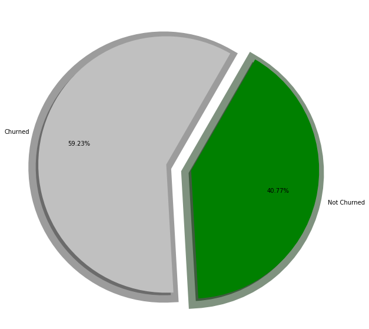

```python
import matplotlib.pyplot as plt
plt.figure(figsize = (10,10))

plt.pie(olist1.Class.value_counts(), autopct = '%1.2f%%',
        explode = [0.0,0.2],
        colors = ['silver', 'green'],
        labels = ['Churned', 'Not Churned'],
       shadow = True, wedgeprops = {'linewidth': 25}  , pctdistance= 0.7, startangle = 60)
plt.show()
```

```python
from sklearn.utils import shuffle
olist2 = shuffle(olist1)
```

```python
olist1.head()
```

|  | customer_zip_code_prefix | order_item_id | price | freight_value | payment_sequential | payment_installments | payment_value | review_score | seller_zip_code_prefix | product_name_lenght | ... | product_Construction | product_Cosmetics_accessories | product_Electronics | product_Furniture | product_Health_Medicinies | product_Households | product_Sports_Fashion | Review_Answer_within_days | Delivery_befor_time | Class |
| --- | --- | --- | --- | --- | --- | --- | --- | --- | --- | --- | --- | --- | --- | --- | --- | --- | --- | --- | --- | --- | --- |
| 0 | 14409 | 1.0 | 124.99 | 21.88 | 1.0 | 2.0 | 146.87 | 4 | 8577.0 | 41.0 | ... | 0 | 0 | 0 | 0 | 0 | 0 | 0 | 4.0 | 3.0 | 1 |
| 1 | 68030 | 1.0 | 112.99 | 24.90 | 1.0 | 1.0 | 275.79 | 1 | 8577.0 | 41.0 | ... | 0 | 0 | 0 | 0 | 0 | 0 | 0 | 2.0 | 5.0 | 1 |
| 2 | 68030 | 2.0 | 112.99 | 24.90 | 1.0 | 1.0 | 275.79 | 1 | 8577.0 | 41.0 | ... | 0 | 0 | 0 | 0 | 0 | 0 | 0 | 2.0 | 5.0 | 1 |
| 3 | 92480 | 1.0 | 124.99 | 15.62 | 1.0 | 7.0 | 140.61 | 3 | 8577.0 | 41.0 | ... | 0 | 0 | 0 | 0 | 0 | 0 | 0 | 1.0 | 4.0 | 1 |
| 4 | 25931 | 1.0 | 106.99 | 30.59 | 1.0 | 10.0 | 137.58 | 4 | 8577.0 | 41.0 | ... | 0 | 0 | 0 | 0 | 0 | 0 | 0 | 1.0 | 10.0 | 1 |

5 rows × 51 columns

We have shuffled the complete data, to avoide consistency.

```python
olist2.head()
```

|  | customer_zip_code_prefix | order_item_id | price | freight_value | payment_sequential | payment_installments | payment_value | review_score | seller_zip_code_prefix | product_name_lenght | ... | product_Construction | product_Cosmetics_accessories | product_Electronics | product_Furniture | product_Health_Medicinies | product_Households | product_Sports_Fashion | Review_Answer_within_days | Delivery_befor_time | Class |
| --- | --- | --- | --- | --- | --- | --- | --- | --- | --- | --- | --- | --- | --- | --- | --- | --- | --- | --- | --- | --- | --- |
| 115622 | 28890 | 1.0 | 177.00 | 15.41 | 1.0 | 10.0 | 192.41 | 5 | 11701.0 | 57.0 | ... | 0 | 0 | 0 | 0 | 0 | 1 | 0 | 2.0 | 3.0 | 1 |
| 65337 | 2252 | 2.0 | 8.88 | 8.29 | 1.0 | 1.0 | 103.02 | 1 | 1512.0 | 56.0 | ... | 0 | 0 | 0 | 0 | 0 | 1 | 0 | 3.0 | 17.0 | 0 |
| 73324 | 19912 | 5.0 | 21.99 | 12.79 | 1.0 | 1.0 | 208.68 | 1 | 14940.0 | 60.0 | ... | 0 | 0 | 0 | 1 | 0 | 0 | 0 | 3.0 | 1.0 | 0 |
| 15409 | 95860 | 2.0 | 199.90 | 27.48 | 1.0 | 1.0 | 454.76 | 5 | 5141.0 | 48.0 | ... | 0 | 0 | 0 | 0 | 0 | 0 | 1 | 0.0 | 6.0 | 0 |
| 83491 | 3160 | 1.0 | 221.99 | 15.64 | 1.0 | 2.0 | 237.63 | 1 | 14940.0 | 58.0 | ... | 0 | 0 | 0 | 0 | 1 | 0 | 0 | 3.0 | 6.0 | 0 |

5 rows × 51 columns

```python
olist2.shape, olist.shape
```

```
((114073, 51), (114073, 50))
```

One columns added in `olist2` is because target variable has been adjusted.

Let us drop unnecessery columns:

```python
olist2.columns
```

```
Index(['customer_zip_code_prefix', 'order_item_id', 'price', 'freight_value',
       'payment_sequential', 'payment_installments', 'payment_value',
       'review_score', 'seller_zip_code_prefix', 'product_name_lenght',
       'product_description_lenght', 'product_photos_qty', 'product_weight_g',
       'product_length_cm', 'product_height_cm', 'product_width_cm',
       'customer_id', 'customer_unique_id', 'customer_city', 'customer_state',
       'order_id', 'order_status', 'order_purchase_timestamp',
       'order_approved_at', 'order_delivered_carrier_date',
       'order_delivered_customer_date', 'order_estimated_delivery_date',
       'Delivered_item_in_days', 'Quickness_in_deliveries_days',
       'Quickness_in_approval_in_days', 'Quickness_in_loading_in_days',
       'product_id', 'seller_id', 'shipping_limit_date', 'payment_type',
       'review_id', 'review_creation_date', 'review_answer_timestamp',
       'seller_city', 'seller_state', 'product_Computer_Office',
       'product_Construction', 'product_Cosmetics_accessories',
       'product_Electronics', 'product_Furniture', 'product_Health_Medicinies',
       'product_Households', 'product_Sports_Fashion',
       'Review_Answer_within_days', 'Delivery_befor_time', 'Class'],
      dtype='object')
```

```python
olist3 = olist2.copy()
```

```python
olist_data = olist3.drop([ 'order_purchase_timestamp', 'order_approved_at',
       'order_delivered_carrier_date', 'order_delivered_customer_date',
       'order_estimated_delivery_date', 'shipping_limit_date', 'review_creation_date',
                         'review_answer_timestamp'], axis = 1)
```

Let us see the complet data again:

```python
olist_data.iloc[:5, 0:6]
```

|  | customer_zip_code_prefix | order_item_id | price | freight_value | payment_sequential | payment_installments |
| --- | --- | --- | --- | --- | --- | --- |
| 115622 | 28890 | 1.0 | 177.00 | 15.41 | 1.0 | 10.0 |
| 65337 | 2252 | 2.0 | 8.88 | 8.29 | 1.0 | 1.0 |
| 73324 | 19912 | 5.0 | 21.99 | 12.79 | 1.0 | 1.0 |
| 15409 | 95860 | 2.0 | 199.90 | 27.48 | 1.0 | 1.0 |
| 83491 | 3160 | 1.0 | 221.99 | 15.64 | 1.0 | 2.0 |

```python
olist_data.iloc[:5, 6:20]
```

|  | payment_value | review_score | seller_zip_code_prefix | product_name_lenght | product_description_lenght | product_photos_qty | product_weight_g | product_length_cm | product_height_cm | product_width_cm | customer_id | customer_unique_id | customer_city | customer_state |
| --- | --- | --- | --- | --- | --- | --- | --- | --- | --- | --- | --- | --- | --- | --- |
| 115622 | 192.41 | 5 | 11701.0 | 57.0 | 2585.0 | 7.0 | 4450.0 | 28.0 | 14.0 | 28.0 | d5ef2005eca8ab3356125c50c6baa8cf | 015366a7c13024e36f1f125d8f9a9e67 | 150 | 14739 |
| 65337 | 103.02 | 1 | 1512.0 | 56.0 | 212.0 | 3.0 | 458.0 | 20.0 | 13.0 | 32.0 | ffbd58aa41cbab07f08190801e939f59 | f74c8f68bd37ba2c2e6e0f5ed1918a46 | 18003 | 48121 |
| 73324 | 208.68 | 1 | 14940.0 | 60.0 | 662.0 | 1.0 | 1150.0 | 22.0 | 4.0 | 28.0 | 08a0a61f98f22952682f7e463ef2d43e | 478098554da8910383d47ec3788a9905 | 96 | 48121 |
| 15409 | 454.76 | 5 | 5141.0 | 48.0 | 236.0 | 2.0 | 3450.0 | 60.0 | 15.0 | 15.0 | a558c27e289c8e4e99cb82e7665ff009 | 7a6b512c983462b8c29e4ec4501c48f7 | 13 | 6332 |
| 83491 | 237.63 | 1 | 14940.0 | 58.0 | 164.0 | 1.0 | 1450.0 | 35.0 | 15.0 | 25.0 | cb59d93b07becb11982cd25188999fe6 | 72ec7c240cdb7e2849af87693d91a7d7 | 18003 | 48121 |

```python
olist_data.iloc[:5, 20:30]
```

|  | order_id | order_status | Delivered_item_in_days | Quickness_in_deliveries_days | Quickness_in_approval_in_days | Quickness_in_loading_in_days | product_id | seller_id | payment_type | review_id |
| --- | --- | --- | --- | --- | --- | --- | --- | --- | --- | --- |
| 115622 | a99bed70b800227cc293174945a645e0 | 1 | 9.0 | 12.000000 | 0.0 | 0.0 | 861857117917aaa99611defcc0d514cd | e9779976487b77c6d4ac45f75ec7afe9 | 1 | 89d199f2f4c925547e12468e7f83c849 |
| 65337 | 2efe3d3b0ddc295d2ce1c43f021078cb | 1 | 22.0 | 12.055692 | 3.0 | 20.0 | 643d903164c4b6ba8bd0b68348e9d135 | bbad7e518d7af88a0897397ffdca1979 | 1 | f54ac87539c637b8a7700f07c1e9e445 |
| 73324 | 2b4d04cfb81d2dbb1ab48f9e2a7ac6b9 | 1 | 6.0 | 12.000000 | 1.0 | 2.0 | ead3077a141a9c800d6a4bb9d0d415b6 | b2479f944e1b90cf8a5de1bbfde284d6 | 0 | 74ef1abcf8bfb7ca756b7cd788ee366b |
| 15409 | daaa1175302ea22f08aede6bd5bee8bf | 1 | 14.0 | 33.000000 | 2.0 | 6.0 | 60f560fe3dd8adc165becf182ec8f834 | 8f2ce03f928b567e3d56181ae20ae952 | 0 | 756adfabe4ee6f0becac8ed5efee062d |
| 83491 | 697c9a80085fcb5f4532d540fbf73e43 | 1 | 11.0 | 14.000000 | 0.0 | 4.0 | 18f97605e88c76affcbfa78ba4e52293 | d1c281d3ae149232351cd8c8cc885f0d | 1 | 7a710f42c16f1263f7d0de02d1fa3341 |

```python
olist_data.iloc[:5, 30:53]
```

|  | seller_city | seller_state | product_Computer_Office | product_Construction | product_Cosmetics_accessories | product_Electronics | product_Furniture | product_Health_Medicinies | product_Households | product_Sports_Fashion | Review_Answer_within_days | Delivery_befor_time | Class |
| --- | --- | --- | --- | --- | --- | --- | --- | --- | --- | --- | --- | --- | --- |
| 115622 | 1348 | 81373 | 0 | 0 | 0 | 0 | 0 | 0 | 1 | 0 | 2.0 | 3.0 | 1 |
| 65337 | 28427 | 81373 | 0 | 0 | 0 | 0 | 0 | 0 | 1 | 0 | 3.0 | 17.0 | 0 |
| 73324 | 8192 | 81373 | 0 | 0 | 0 | 0 | 1 | 0 | 0 | 0 | 3.0 | 1.0 | 0 |
| 15409 | 173 | 81373 | 0 | 0 | 0 | 0 | 0 | 0 | 0 | 1 | 0.0 | 6.0 | 0 |
| 83491 | 8192 | 81373 | 0 | 0 | 0 | 0 | 0 | 1 | 0 | 0 | 3.0 | 6.0 | 0 |

Finally the data is ready for further proceedings.

```python
olist_data.shape
```

```
(114073, 43)
```

```python
len(olist_data.customer_id.unique()), len(olist_data.customer_unique_id.unique())
```

```
(95128, 92081)
```

```python
olist_data1 = olist_data.copy()
olist_data1 = olist_data1.drop(['order_id', 'product_id', 'seller_id', 'review_id',
    'customer_zip_code_prefix', 'order_item_id', 'customer_id'], axis = 1)
olist_data1['customer_unique_id'] = olist_data1.groupby(['customer_unique_id'], sort=False).ngroup().add(1)
olist_data1.set_index('customer_unique_id', drop = True, inplace=True)
```

```python
len(olist_data1.index.unique()), len(olist_data.customer_unique_id.unique())
```

```
(92081, 92081)
```

```python
olist_data1.head()
```

| customer_unique_id | price | freight_value | payment_sequential | payment_installments | payment_value | review_score | seller_zip_code_prefix | product_name_lenght | product_description_lenght | product_photos_qty | ... | product_Construction | product_Cosmetics_accessories | product_Electronics | product_Furniture | product_Health_Medicinies | product_Households | product_Sports_Fashion | Review_Answer_within_days | Delivery_befor_time | Class |
| --- | --- | --- | --- | --- | --- | --- | --- | --- | --- | --- | --- | --- | --- | --- | --- | --- | --- | --- | --- | --- | --- |
| 1 | 177.00 | 15.41 | 1.0 | 10.0 | 192.41 | 5 | 11701.0 | 57.0 | 2585.0 | 7.0 | ... | 0 | 0 | 0 | 0 | 0 | 1 | 0 | 2.0 | 3.0 | 1 |
| 2 | 8.88 | 8.29 | 1.0 | 1.0 | 103.02 | 1 | 1512.0 | 56.0 | 212.0 | 3.0 | ... | 0 | 0 | 0 | 0 | 0 | 1 | 0 | 3.0 | 17.0 | 0 |
| 3 | 21.99 | 12.79 | 1.0 | 1.0 | 208.68 | 1 | 14940.0 | 60.0 | 662.0 | 1.0 | ... | 0 | 0 | 0 | 1 | 0 | 0 | 0 | 3.0 | 1.0 | 0 |
| 4 | 199.90 | 27.48 | 1.0 | 1.0 | 454.76 | 5 | 5141.0 | 48.0 | 236.0 | 2.0 | ... | 0 | 0 | 0 | 0 | 0 | 0 | 1 | 0.0 | 6.0 | 0 |
| 5 | 221.99 | 15.64 | 1.0 | 2.0 | 237.63 | 1 | 14940.0 | 58.0 | 164.0 | 1.0 | ... | 0 | 0 | 0 | 0 | 1 | 0 | 0 | 3.0 | 6.0 | 0 |

5 rows × 35 columns

```python
from collections import Counter
counter_ind = Counter(olist_data1.index)

olist_data1['Order_frequency'] = olist_data1.index.map(counter_ind)
```

```python
olist_data1.columns
```

```
Index(['price', 'freight_value', 'payment_sequential', 'payment_installments',
       'payment_value', 'review_score', 'seller_zip_code_prefix',
       'product_name_lenght', 'product_description_lenght',
       'product_photos_qty', 'product_weight_g', 'product_length_cm',
       'product_height_cm', 'product_width_cm', 'customer_city',
       'customer_state', 'order_status', 'Delivered_item_in_days',
       'Quickness_in_deliveries_days', 'Quickness_in_approval_in_days',
       'Quickness_in_loading_in_days', 'payment_type', 'seller_city',
       'seller_state', 'product_Computer_Office', 'product_Construction',
       'product_Cosmetics_accessories', 'product_Electronics',
       'product_Furniture', 'product_Health_Medicinies', 'product_Households',
       'product_Sports_Fashion', 'Review_Answer_within_days',
       'Delivery_befor_time', 'Class', 'Order_frequency'],
      dtype='object')
```

```python
olist_data1 = olist_data1.drop(['customer_city', 'seller_city', 'seller_state', 'seller_zip_code_prefix',
                               'customer_state'], axis = 1)
```

```python
olist_data1.head()
```

| customer_unique_id | price | freight_value | payment_sequential | payment_installments | payment_value | review_score | product_name_lenght | product_description_lenght | product_photos_qty | product_weight_g | ... | product_Cosmetics_accessories | product_Electronics | product_Furniture | product_Health_Medicinies | product_Households | product_Sports_Fashion | Review_Answer_within_days | Delivery_befor_time | Class | Order_frequency |
| --- | --- | --- | --- | --- | --- | --- | --- | --- | --- | --- | --- | --- | --- | --- | --- | --- | --- | --- | --- | --- | --- |
| 1 | 177.00 | 15.41 | 1.0 | 10.0 | 192.41 | 5 | 57.0 | 2585.0 | 7.0 | 4450.0 | ... | 0 | 0 | 0 | 0 | 1 | 0 | 2.0 | 3.0 | 1 | 1 |
| 2 | 8.88 | 8.29 | 1.0 | 1.0 | 103.02 | 1 | 56.0 | 212.0 | 3.0 | 458.0 | ... | 0 | 0 | 0 | 0 | 1 | 0 | 3.0 | 17.0 | 0 | 6 |
| 3 | 21.99 | 12.79 | 1.0 | 1.0 | 208.68 | 1 | 60.0 | 662.0 | 1.0 | 1150.0 | ... | 0 | 0 | 1 | 0 | 0 | 0 | 3.0 | 1.0 | 0 | 6 |
| 4 | 199.90 | 27.48 | 1.0 | 1.0 | 454.76 | 5 | 48.0 | 236.0 | 2.0 | 3450.0 | ... | 0 | 0 | 0 | 0 | 0 | 1 | 0.0 | 6.0 | 0 | 2 |
| 5 | 221.99 | 15.64 | 1.0 | 2.0 | 237.63 | 1 | 58.0 | 164.0 | 1.0 | 1450.0 | ... | 0 | 0 | 0 | 1 | 0 | 0 | 3.0 | 6.0 | 0 | 1 |

5 rows × 31 columns

```python
olist_data1.columns
```

```
Index(['price', 'freight_value', 'payment_sequential', 'payment_installments',
       'payment_value', 'review_score', 'product_name_lenght',
       'product_description_lenght', 'product_photos_qty', 'product_weight_g',
       'product_length_cm', 'product_height_cm', 'product_width_cm',
       'order_status', 'Delivered_item_in_days',
       'Quickness_in_deliveries_days', 'Quickness_in_approval_in_days',
       'Quickness_in_loading_in_days', 'payment_type',
       'product_Computer_Office', 'product_Construction',
       'product_Cosmetics_accessories', 'product_Electronics',
       'product_Furniture', 'product_Health_Medicinies', 'product_Households',
       'product_Sports_Fashion', 'Review_Answer_within_days',
       'Delivery_befor_time', 'Class', 'Order_frequency'],
      dtype='object')
```

```python
OLIST = olist_data1[['price', 'freight_value', 'payment_sequential', 'payment_installments',
       'payment_value', 'review_score', 'product_name_lenght',
       'product_description_lenght', 'product_photos_qty', 'product_weight_g',
       'product_length_cm', 'product_height_cm', 'product_width_cm',
       'order_status', 'Delivered_item_in_days',
       'Quickness_in_deliveries_days', 'Quickness_in_approval_in_days',
       'Quickness_in_loading_in_days', 'payment_type',
       'product_Computer_Office', 'product_Construction',
       'product_Cosmetics_accessories', 'product_Electronics',
       'product_Furniture', 'product_Health_Medicinies', 'product_Households',
       'product_Sports_Fashion', 'Review_Answer_within_days',
       'Delivery_befor_time', 'Order_frequency', 'Class']]
OLIST.head()
```

| customer_unique_id | price | freight_value | payment_sequential | payment_installments | payment_value | review_score | product_name_lenght | product_description_lenght | product_photos_qty | product_weight_g | ... | product_Cosmetics_accessories | product_Electronics | product_Furniture | product_Health_Medicinies | product_Households | product_Sports_Fashion | Review_Answer_within_days | Delivery_befor_time | Order_frequency | Class |
| --- | --- | --- | --- | --- | --- | --- | --- | --- | --- | --- | --- | --- | --- | --- | --- | --- | --- | --- | --- | --- | --- |
| 1 | 177.00 | 15.41 | 1.0 | 10.0 | 192.41 | 5 | 57.0 | 2585.0 | 7.0 | 4450.0 | ... | 0 | 0 | 0 | 0 | 1 | 0 | 2.0 | 3.0 | 1 | 1 |
| 2 | 8.88 | 8.29 | 1.0 | 1.0 | 103.02 | 1 | 56.0 | 212.0 | 3.0 | 458.0 | ... | 0 | 0 | 0 | 0 | 1 | 0 | 3.0 | 17.0 | 6 | 0 |
| 3 | 21.99 | 12.79 | 1.0 | 1.0 | 208.68 | 1 | 60.0 | 662.0 | 1.0 | 1150.0 | ... | 0 | 0 | 1 | 0 | 0 | 0 | 3.0 | 1.0 | 6 | 0 |
| 4 | 199.90 | 27.48 | 1.0 | 1.0 | 454.76 | 5 | 48.0 | 236.0 | 2.0 | 3450.0 | ... | 0 | 0 | 0 | 0 | 0 | 1 | 0.0 | 6.0 | 2 | 0 |
| 5 | 221.99 | 15.64 | 1.0 | 2.0 | 237.63 | 1 | 58.0 | 164.0 | 1.0 | 1450.0 | ... | 0 | 0 | 0 | 1 | 0 | 0 | 3.0 | 6.0 | 1 | 0 |

5 rows × 31 columns

```python
OLIST.to_csv('OLIST.csv')
```

```python
OLIST_final = OLIST[~OLIST.index.duplicated(keep='first')]
```

```python
OLIST_final.shape, olist_data1.shape
```

```
((92081, 31), (114073, 31))
```

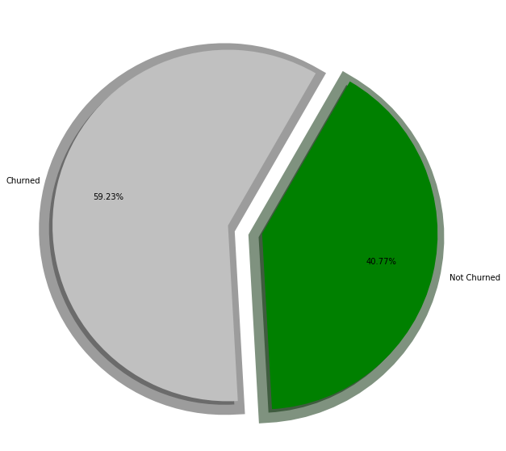

```python
import matplotlib.pyplot as plt
plt.figure(figsize = (10,10))

plt.pie(OLIST.Class.value_counts(), autopct = '%1.2f%%',
        explode = [0.0,0.2],
        colors = ['silver', 'green'],
        labels = ['Churned', 'Not Churned'],
       shadow = True, wedgeprops = {'linewidth': 25}  , pctdistance= 0.7, startangle = 60)
plt.show()
```